# ISLR_Ch5_CV_and_Bootstrap

Steve Newns

April 27, 2018

## 5.3 Lab: Cross-Validation and the Bootstrap

### 5.3.1 The Validation Set Approach

We explore the use of the validation set approach in order to estimate test error rates that result from fitting various linear models on `Auto`

```r
library(ISLR)
library(caTools)
library(tidyverse)
library(caret)
library(mosaic)
library(boot) # cv.glm()

set.seed(1)
train = sample(392,196)

lm_fit <- lm(mpg ~ horsepower, Auto, subset=train)
msummary(lm_fit)
```

```
##              Estimate Std. Error t value Pr(>|t|)
## (Intercept) 40.340377   1.002269   40.25   <2e-16 ***
## horsepower  -0.161701   0.008809  -18.36   <2e-16 ***
##
## Residual standard error: 4.692 on 194 degrees of freedom
## Multiple R-squared:  0.6346, Adjusted R-squared:  0.6327
## F-statistic: 336.9 on 1 and 194 DF,  p-value: < 2.2e-16
```

Now use `predict()` to estimate the response for all 392 observations, + use `mean()` to calculate $MSE$ of the 196 observations in the validation set.

```r
attach(Auto)
(mse_auto <- mean((mpg - predict(lm_fit, Auto))[-train]^2))
```

```
## [1] 26.14142
```

Estimated test MSE for the linear regression fit = 26.14. Can use `poly()` to estimate the test error for the quadratic and cubic regressions

```r
quad_lm_fit <- lm(mpg ~ poly(horsepower,2), Auto, subset=train)
cubic_lm_fit <- lm(mpg ~ poly(horsepower,3), Auto, subset=train)

(quad_mse_auto <- mean((mpg - predict(quad_lm_fit, Auto))[-train]^2))
```

```
## [1] 19.82259
```

```r
(cubic_mse_auto <- mean((mpg - predict(cubic_lm_fit, Auto))[-train]^2))
```

```
## [1] 19.78252
```

If we choose a different training set instead, then we will obtain somewhat different errors on the validation set.

```r
set.seed(2)
train = sample(392,196)

lm_fit <- lm(mpg ~ horsepower, Auto, subset=train)
quad_lm_fit <- lm(mpg ~ poly(horsepower,2), Auto, subset=train)
cubic_lm_fit <- lm(mpg ~ poly(horsepower,3), Auto, subset=train)

(mse_auto <- mean((mpg - predict(lm_fit, Auto))[-train]^2))
```

```
## [1] 23.29559
```

```r
(quad_mse_auto <- mean((mpg - predict(quad_lm_fit, Auto))[-train]^2))
```

```
## [1] 18.90124
```

```r
(cubic_mse_auto <- mean((mpg - predict(cubic_lm_fit, Auto))[-train]^2))
```

```
## [1] 19.2574
```

These results are consistent with previous findings: a model that predicts `mpg` using a quadratic function of `horsepower` performs better than a model that involves only a linear function of `horsepower`, and there is little evidence in favor of a model that uses a cubic function of `horsepower`.

### 5.3.2 Leave-One-Out Cross-Validation

The **LOOCV** estimate can be automatically computed for any GLM using `glm()` and `cv.glm()`.

```r
glm_fit <- glm(mpg~horsepower,data=Auto)
coef(glm_fit)
```

```
## (Intercept)  horsepower
##  39.9358610  -0.1578447
```

`glm()` can be used together with `cv.glm()` from `boot` while `lm()` cannot. It produces a list w/ several components. The 2 numbers in the `delta` vector contain the CV results for the test error:

```r
cv_err=cv.glm(Auto, glm_fit)
cv_err$delta
```

```
## [1] 24.23151 24.23114
```

In this case the numbers = identical (up to 2 decimal places) + correspond to the LOOCV statistic given in $CV_(n) = \frac {1} {n} \sum_{i=1}^n MSE_i$. Below, we discuss a situation in which the 2 #’s differ. Our CV estimate is approximately 24.23.

We can repeat this procedure for increasingly complex polynomial fits. To automate the process, use 1for()1 to initiate a **for loop** to iteratively fit polynomial regressions for polynomials of order $i = 1$ to $i = 5$, compute associated CV error, + store it in the $i$th element of the vector `cv_error`.

```r
cv_err <- rep(0, 5)
xs <- rep(0, 5)

for (i in 1:5) {
  glm_fit <- glm(mpg ~ poly(horsepower, i), data = Auto)
  xs[i] <- i
  cv_err[i] <- cv.glm(Auto, glm_fit)$delta[1]
}

cv_err
```

```
## [1] 24.23151 19.24821 19.33498 19.42443 19.03321
```

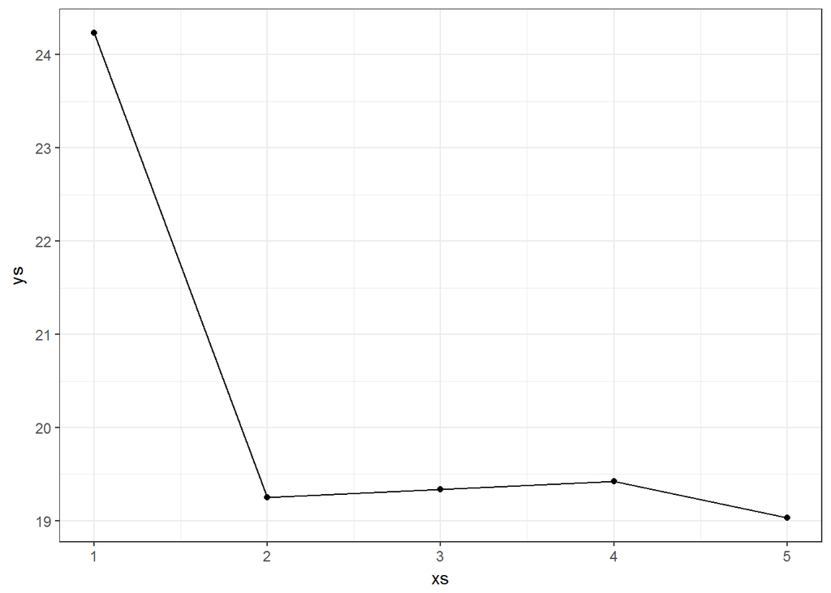

```r
df <- data.frame(xs = xs, ys = cv_err)
ggplot(df,aes(xs,ys)) + geom_point() + geom_line() + theme_bw()
```

See a sharp drop in the estimated test MSE between linear + quadratic fits, but no clear improvement onward.